# Project Python Foundations: FoodHub Data Analysis

### Context

The number of restaurants in New York is increasing day by day. Lots of students and busy professionals rely on those restaurants due to their hectic lifestyles. Online food delivery service is a great option for them. It provides them with good food from their favorite restaurants. A food aggregator company FoodHub offers access to multiple restaurants through a single smartphone app.

The app allows the restaurants to receive a direct online order from a customer. The app assigns a delivery person from the company to pick up the order after it is confirmed by the restaurant. The delivery person then uses the map to reach the restaurant and waits for the food package. Once the food package is handed over to the delivery person, he/she confirms the pick-up in the app and travels to the customer's location to deliver the food. The delivery person confirms the drop-off in the app after delivering the food package to the customer. The customer can rate the order in the app. The food aggregator earns money by collecting a fixed margin of the delivery order from the restaurants.

### Objective

The food aggregator company has stored the data of the different orders made by the registered customers in their online portal. They want to analyze the data to get a fair idea about the demand of different restaurants which will help them in enhancing their customer experience. Suppose you are hired as a Data Scientist in this company and the Data Science team has shared some of the key questions that need to be answered. Perform the data analysis to find answers to these questions that will help the company to improve the business.

### Data Description

The data contains the different data related to a food order. The detailed data dictionary is given below.

### Data Dictionary

- order_id: Unique ID of the order
- customer_id: ID of the customer who ordered the food
- restaurant_name: Name of the restaurant
- cuisine_type: Cuisine ordered by the customer
- cost_of_the_order: Cost of the order
- day_of_the_week: Indicates whether the order is placed on a weekday or weekend (The weekday is from Monday to Friday and the weekend is Saturday and Sunday)
- rating: Rating given by the customer out of 5
- food_preparation_time: Time (in minutes) taken by the restaurant to prepare the food. This is calculated by taking the difference between the timestamps of the restaurant's order confirmation and the delivery person's pick-up confirmation.
- delivery_time: Time (in minutes) taken by the delivery person to deliver the food package. This is calculated by taking the difference between the timestamps of the delivery person's pick-up confirmation and drop-off information

### Let us start by importing the required libraries

Student: Robert Partee

```python
#########################################################################
#
# Student: Robert Partee
#
##########################################################################
```

```python
# Installing the libraries with the specified version.
!pip install numpy==1.25.2 pandas==1.5.3 matplotlib==3.7.1 seaborn==0.13.1 -q --user
```

[output not shown]

**Note**: *After running the above cell, kindly restart the notebook kernel and run all cells sequentially from the start again.*

```python
# import libraries for data manipulation
import numpy as np
import pandas as pd

# import libraries for data visualization
import matplotlib.pyplot as plt
import seaborn as sns
```

### Understanding the structure of the data

```python
# uncomment and run the following lines for Google Colab
# from google.colab import drive
# drive.mount('/content/drive')
#from google.colab import drive
#drive.mount("/Users/robpartee/P1_Project/Texas-McCombs-ML-AI/foodhub")
```

```python
# Write your code here to read the data
food_data = pd.read_csv("foodhub_order.csv")
```

```python
# Write your code here to view the first 5 rows
#print ("The the first 5 rows:")
food_data.head(5)
#print ("==========================================================")
#print ("Answer complete...")
```

|  | order_id | customer_id | restaurant_name | cuisine_type | cost_of_the_order | day_of_the_week | rating | food_preparation_time | delivery_time |
| --- | --- | --- | --- | --- | --- | --- | --- | --- | --- |
| 0 | 1477147 | 337525 | Hangawi | Korean | 30.75 | Weekend | Not given | 25 | 20 |
| 1 | 1477685 | 358141 | Blue Ribbon Sushi Izakaya | Japanese | 12.08 | Weekend | Not given | 25 | 23 |
| 2 | 1477070 | 66393 | Cafe Habana | Mexican | 12.23 | Weekday | 5 | 23 | 28 |
| 3 | 1477334 | 106968 | Blue Ribbon Fried Chicken | American | 29.20 | Weekend | 3 | 25 | 15 |
| 4 | 1478249 | 76942 | Dirty Bird to Go | American | 11.59 | Weekday | 4 | 25 | 24 |

### **Question 1:** How many rows and columns are present in the data? [0.5 mark]

```python
# Write your code here
food_data.describe()
temp = np.array(food_data)
num_rows, num_cols = temp.shape
print ("The number of rows: {0}".format(num_rows))
print ("The number of cols: {0}".format(num_cols))
```

```
The number of rows: 1898
The number of cols: 9
```

#### Observations:

### **Question 2:** What are the datatypes of the different columns in the dataset? (The info() function can be used) [0.5 mark]

```python
# Write your code here
print ("The datatype of the different columns are listed below\n")
print (food_data.info())
print ("============== Answer is complete ==================")
# Note:
#   object types are str
#
```

```
The datatype of the different columns are listed below

<class 'pandas.core.frame.DataFrame'>
RangeIndex: 1898 entries, 0 to 1897
Data columns (total 9 columns):
 #   Column                 Non-Null Count  Dtype
---  ------                 --------------  -----
 0   order_id               1898 non-null   int64
 1   customer_id            1898 non-null   int64
 2   restaurant_name        1898 non-null   object
 3   cuisine_type           1898 non-null   object
 4   cost_of_the_order      1898 non-null   float64
 5   day_of_the_week        1898 non-null   object
 6   rating                 1898 non-null   object
 7   food_preparation_time  1898 non-null   int64
 8   delivery_time          1898 non-null   int64
dtypes: float64(1), int64(4), object(4)
memory usage: 133.6+ KB
None
============== Answer is complete ==================
```

#### Observations:

### **Question 3:** Are there any missing values in the data? If yes, treat them using an appropriate method. [1 mark]

Answer: Based on the code below there is no data missing

```python
# Write your code here
# Mothod #1 of 2
print ("Are there any missing values in the data")
print (food_data.isnull().sum())

# Method #2 or 2
missing_values = food_data.isnull()
print("\n The Missing values are listed below")
print (missing_values)
print ("\n----------------------------------")

print ("\n The number of Missing values are {0} ".format(food_data.isnull().sum().sum()))
print ("\n====== Answer is complete =====")
```

```
Are there any missing values in the data
order_id                 0
customer_id              0
restaurant_name          0
cuisine_type             0
cost_of_the_order        0
day_of_the_week          0
rating                   0
food_preparation_time    0
delivery_time            0
dtype: int64

 The Missing values are listed below
      order_id  customer_id  restaurant_name  cuisine_type  cost_of_the_order  \
0        False        False            False         False              False
1        False        False            False         False              False
2        False        False            False         False              False
3        False        False            False         False              False
4        False        False            False         False              False
...        ...          ...              ...           ...                ...
1893     False        False            False         False              False
1894     False        False            False         False              False
1895     False        False            False         False              False
1896     False        False            False         False              False
1897     False        False            False         False              False

      day_of_the_week  rating  food_preparation_time  delivery_time
0               False   False                  False          False
1               False   False                  False          False
2               False   False                  False          False
3               False   False                  False          False
4               False   False                  False          False
...               ...     ...                    ...            ...
1893            False   False                  False          False
1894            False   False                  False          False
1895            False   False                  False          False
1896            False   False                  False          False
1897            False   False                  False          False

[1898 rows x 9 columns]

----------------------------------

 The number of Missing values are 0

====== Answer is complete =====
```

#### Observations:

### **Question 4:** Check the statistical summary of the data. What is the minimum, average, and maximum time it takes for food to be prepared once an order is placed? [2 marks]

```python
# Write your code here
food_prep_max = food_data["food_preparation_time"].max()
food_prep_min = food_data["food_preparation_time"].min()
food_prep_avg = food_data["food_preparation_time"].mean()
print ("\n------------------------------------------------------------------------------------------")
print ("Food Prep Max Time: {0}   Food Prep Min Time: {1}    Food Prep Avg Time: {2}".format(food_prep_max, food_prep_min,food_prep_avg))
print ("--------------------------------------------------------------------------------------------\n")
print ("\n================= Answer complete =============================")
```

```
------------------------------------------------------------------------------------------
Food Prep Max Time: 35   Food Prep Min Time: 20    Food Prep Avg Time: 27.371970495258168
--------------------------------------------------------------------------------------------


================= Answer complete =============================
```

#### Observations:

### **Question 5:** How many orders are not rated? [1 mark]

```python
# Write the code here

not_rated_count = food_data[food_data['rating'] == 'Not given'].shape[0]
print(f"\n Number of orders not rated: {not_rated_count}")
print ("\n The total number of rows: {0}".format(num_rows))
print ("\n the percent missing is {0} ".format((not_rated_count/num_rows) * 100))
print ("\n The number of missing seems small and insignficant ")
print ("\n================= Answer complete =============================")
```

[output not shown]

#### Observations:

### Exploratory Data Analysis (EDA)

### **Question 6:** Explore all the variables and provide observations on their distributions. (Generally, histograms, boxplots, countplots, etc. are used for univariate exploration.) [9 marks]

```
 Items: ['order_id' 'customer_id' 'restaurant_name' 'cuisine_type'
 'cost_of_the_order' 'day_of_the_week' 'rating' 'food_preparation_time'
 'delivery_time']

	 Column Name: order_id  Mean:1477495.5 Std:548.0497240214614

	 Column Name: customer_id  Mean:171168.478398314 Std:113698.13974303949

	 Column Name: cost_of_the_order  Mean:16.498851422550054 Std:7.48381211004957

	 Column Name: food_preparation_time  Mean:27.371970495258168 Std:4.6324807759288555

	 Column Name: delivery_time  Mean:24.161749209694417 Std:4.972636933991106

------ Box Plots -----------------------------------------
```

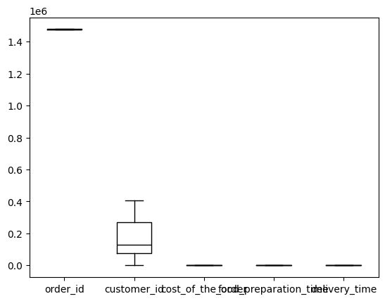

```
------ Histograms ----------------------------------------
```

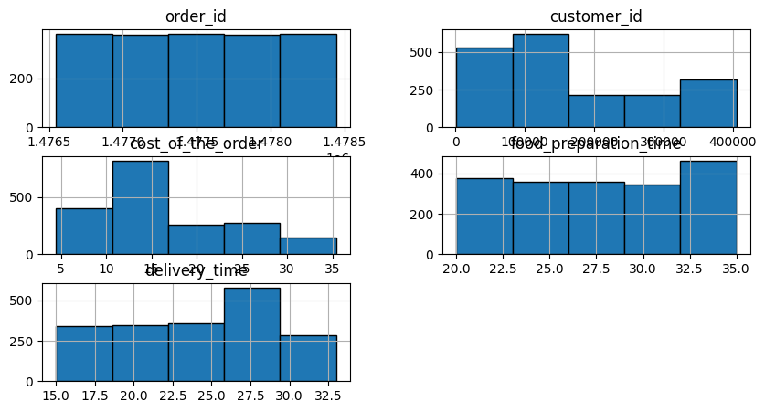

```
===== Answer is complete =============================
```

```python
# Write the code here
from pandas.api.types import is_string_dtype
from pandas.api.types import is_numeric_dtype

items = food_data.columns.values
print ("\n Items: {0}".format(items))

for item in items:
    if (is_numeric_dtype(food_data[item])):
        print ("\n\t Column Name: {0}  Mean:{1} Std:{2}".format( item,food_data[item].mean(), food_data[item].std() ))
    #food_data.boxplot([item], grid=True, color = 'black')
print ("\n------ Box Plots -----------------------------------------\n")

food_data.boxplot(grid=False, color='black')
plt.show()
print ("\n------ Histograms ----------------------------------------\n")
# Create histograms for all columns
food_data.hist(bins=5, figsize=(10, 5), edgecolor='black')
# Show the plot
plt.show()

print ("\n===== Answer is complete =============================")
```

### **Question 7**: Which are the top 5 restaurants in terms of the number of orders received? [1 mark]

```python
# Write the code here
# Method #1 of 2
print ("\n------- Method #1 of 2 to get the top 5 restaraunts \n")
top_restaurants = food_data.groupby('restaurant_name').size().reset_index(name='order_count')
# Sort by order_count in descending order and get the top 5
top_5_restaurants = top_restaurants.sort_values(by='order_count', ascending=False).head(5)

print(top_5_restaurants)

# Method #2 of 2
print ("\n------- Method #2 of 2 to get the top 5 restaraunts \n")
#popular_places = food_data['restaurant_name'].value_counts().values.tolist()[:5]
#print (popular_places)

popular = food_data.value_counts('restaurant_name')
print (popular.head(5))
print ("\n ======= Answer is complete ============")
```

```
------- Method #1 of 2 to get the top 5 restaraunts

               restaurant_name  order_count
136                Shake Shack          219
153          The Meatball Shop          132
21           Blue Ribbon Sushi          119
20   Blue Ribbon Fried Chicken           96
109                       Parm           68

------- Method #2 of 2 to get the top 5 restaraunts

restaurant_name
Shake Shack                  219
The Meatball Shop            132
Blue Ribbon Sushi            119
Blue Ribbon Fried Chicken     96
Parm                          68
Name: count, dtype: int64

 ======= Answer is complete ============
```

#### Observations:

### **Question 8**: Which is the most popular cuisine on weekends? [1 mark]

```python
# Write the code here
print ("\n ---- Method #1 of 2 -----------------------\n")
# create a weekend dataframe
weekend_df = food_data[food_data['day_of_the_week'].isin(['Saturday', 'Sunday'])]

# Group by cuisine_type and count the number of orders
cuisine_counts = weekend_df['cuisine_type'].value_counts()

# Get the most popular cuisine
most_popular_cuisine = cuisine_counts

print("\nThe most popular cuisine on weekends is: {0}".format(most_popular_cuisine))

print ("\n ---- Method #2 of 2 -----------------------\n")
val = 'Weekend'
popular_weekend = food_data.query('day_of_the_week == @val')
popular_food = popular_weekend['cuisine_type'].value_counts().values.tolist()[:5]
print (popular_food)


popular = popular_weekend.value_counts('cuisine_type')
print (popular.head(5))
print ("\n ======= Answer is complete ============")
```

```
 ---- Method #1 of 2 -----------------------


The most popular cuisine on weekends is: Series([], Name: count, dtype: int64)

 ---- Method #2 of 2 -----------------------

[415, 335, 207, 163, 53]
cuisine_type
American    415
Japanese    335
Italian     207
Chinese     163
Mexican      53
Name: count, dtype: int64

 ======= Answer is complete ============
```

#### Observations:

### **Question 9**: What percentage of the orders cost more than 20 dollars? [2 marks]

```python
# Write the code here

print ("\n ----Method #1 of 2 ---------------------------")
total_num_orders = len(food_data)

# Filter orders with cost greater than $20
orders_above_20 = food_data[food_data['cost_of_the_order'] > 20]

# Calculate the number of orders with cost greater than $20
num_orders_above_20 = len(orders_above_20)

# Calculate the percentage
percent_above_20 = (num_orders_above_20 / total_num_orders) * 100

print ("\nThe percentage of orders that cost more than $20 is:{0}".format( percent_above_20))

print ("\n --- Method #2 of 2 ------------------------------")
val20 = 20.00
total_count = food_data['cost_of_the_order'].count()
twenty_and_more = food_data.query('cost_of_the_order >= @val20').count()
#print (total_count, twenty_and_more[0])
print ("\n The percent of order that cost more then $20.00 is {0}".format((twenty_and_more[0] / total_count) * 100 ))
print ("\n===== Answer is complete ================================")
```

```
 ----Method #1 of 2 ---------------------------

The percentage of orders that cost more than $20 is:29.24130663856691

 --- Method #2 of 2 ------------------------------

 The percent of order that cost more then $20.00 is 29.24130663856691

===== Answer is complete ================================
```

### **Question 10**: What is the mean order delivery time? [1 mark]

```python
# Write the code here
print ("-"*47)
print ("\n The mean order delivery time is {0}".format(food_data['delivery_time'].mean()))
print ("="*5, " Answer is complete ", "="*20)
```

```
-----------------------------------------------

 The mean order delivery time is 24.161749209694417
=====  Answer is complete  ====================
```

#### Observations:

### **Question 11:** The company has decided to give 20% discount vouchers to the top 3 most frequent customers. Find the IDs of these customers and the number of orders they placed. [1 mark]

```python
# Write the code here

print ("\n ---  --------------------------------")
customer_frequency = food_data['customer_id'].value_counts()

# Identify the top 3 most frequent customers
top_customers = customer_frequency.head(3)

print (top_customers)
print ("\n===== Answer is complete ================================")
```

```
 ---  --------------------------------
customer_id
52832    13
47440    10
83287     9
Name: count, dtype: int64

===== Answer is complete ================================
```